# Modelos de Clasificación

## Modelos de Regresión: Clasificación de materias.

Pasos para la generación de los modelos de regresión:

1. Cargamos información, agregamos datos sociodemográficos y limpiamos para generar los modelos de clasificación.
2. Realizamos regresión logística multinomial:

2.1. Clasificación de materias considerando todas las variables.

2.2. Clasificación de materia considerando sólo las variables sociodemográficas.

**NOTA:** Se toma a la materia “Común” como la categoría de referencia.

3. Determinamos qué coeficientes son relevantes de la siguiente manera:

3.1. Calculamos la puntuación Z para cada coeficiente.

3.2. Convertimos a valores P.

3.3. Calculamos cambio en probabilidad de cada factor para generar cada materia.

Coeficientes más relevantes para primer modelo: Clasificación de materias considerando todas las variables:

```
##                                                    Administrativa
## escuelaUniversidad Nacional del sureste               6744.988772
## escuelaInstituto de Ciencias Autonomo de Zacatecas    1603.305282
## escuelaUniversidad Autonoma de Sonora                 1369.695695
## instanciaTribunales Colegiados de Circuito              37.402156
## instanciaPleno                                          27.302350
## instanciaSala Auxiliar                                  23.872629
## instanciaSegunda Sala                                   14.606044
## edoMorelos                                              10.380390
## epocaSexta Época                                         7.727643
## epocaSéptima Época                                       6.783961
```

```
##                                                                  Civil
## instanciaTribunales Colegiados de Circuito                1990067.3940
## instanciaTercera Sala                                      998882.4335
## escuelaEscuela de Jurisprudencia de la Ciudad Guadalajara  882350.1031
## instanciaSala Auxiliar                                     280127.6546
## instanciaPrimera Sala                                      104519.0577
## instanciaPleno                                              39721.7342
## escuelaUniversidad de Occidente                              4482.6699
## instanciaSegunda Sala                                        3859.3293
## escuelaUniversidad Autonoma de Sonora                         335.8299
## edoMorelos                                                    178.5079
```

```
##                                                    Constitucional
## instanciaPleno                                          19.803948
## instanciaSala Auxiliar                                  13.424250
## escuelaInstituto de Ciencias Autonomo de Zacatecas       4.718398
## instanciaPrimera Sala                                    4.127663
## edoZacatecas                                             3.431920
## instanciaSegunda Sala                                    2.794483
## escuelaUniversidad Autonoma de Sonora                    2.742461
## escuelaUniversidad Valle del Bravo                       2.592282
## generacionGeneracion X                                   2.463613
## generacionSegunda GM                                     2.134866
```

```
##                                     Laboral
## escuelaUniversidad del Tepeyac 198710.00666
## edoMichoacan                       38.00067
## edoColima                          35.88209
## edoEstado de Mexico                33.74849
## edoSonora                          29.02200
## edoZacatecas                       24.73804
## edoHidalgo                         23.58178
## edoDurango                         20.98131
## edoChiapas                         20.45823
## edoQueretaro                       19.77194
```

```
##                                                           Penal
## escuelaUniversidad Valle del Bravo                 2246242.6381
## instanciaTribunales Colegiados de Circuito          252327.3130
## escuelaUniversidad Autonoma de Sonora               129944.4625
## instanciaPrimera Sala                                85853.9666
## escuelaColegio de San Nicolas                        51533.3540
## escuelaInstituto de Ciencias Autonomo de Zacatecas   49868.3131
## escuelaUniversidad de Occidente                      27398.5341
## escuelaUniversidad de San Luis Potosi                 7090.7683
## instanciaPleno                                        3039.5287
## escuelaUniversidad Autonoma de Veracruz Villa Rica     107.2141
```

Coeficientes más relevantes para segundo modelo: Clasificación de materias considerando sólo las variables sociodemográficas:

```
##                                                    Administrativa
## escuelaInstituto de Ciencias Autonomo de Zacatecas    5907.972184
## escuelaUniversidad Nacional del sureste               3070.608255
## escuelaUniversidad Autonoma de Sonora                  302.322278
## edoMorelos                                              10.684316
## (Intercept)                                              4.767993
## escuelaUniversidad de San Luis Potosi                    3.432895
## escuelaUniversidad Autonoma de Campeche                  2.713763
## escuelaUniversidad de Campeche                           2.432745
## generacionPrevios                                        2.289967
## edoYucatan                                               1.524032
```

```
##                                                                  Civil
## escuelaEscuela de Jurisprudencia de la Ciudad Guadalajara 24080.479192
## escuelaUniversidad de Occidente                            2328.084388
## edoMorelos                                                  119.285242
## escuelaUniversidad Autonoma de Sonora                        55.996018
## edoSonora                                                    10.791345
## edoTabasco                                                   10.378704
## edoEstado de Mexico                                           3.687014
## edoPuebla                                                     2.791665
## escuelaUniversidad Autonoma de Chiapas                        2.388355
## edoNayarit                                                    2.271711
```

```
##                                       Constitucional
## generacionSegunda GM                        2.816922
## (Intercept)                                 2.762457
## generacionPost Guerra                       2.618392
## generacionGeneracion X                      2.483619
## generacionPrevios                           2.394744
## generacionBoomers II                        2.311513
## generacionDepresion                         2.281391
## escuelaUniversidad Valle del Bravo          2.237863
## escuelaUniversidad Autonoma de Sonora       1.918441
## escuelaColegio de San Nicolas               1.393690
```

```
##                                             Laboral
## escuelaUniversidad del Tepeyac         3.639626e+06
## escuelaUniversidad Autonoma de Sinaloa 1.693136e+02
## edoEstado de Mexico                    2.798749e+01
## escuelaUniversidad Autonoma de Morelos 2.786924e+01
## edoSonora                              2.735548e+01
## edoQueretaro                           2.458419e+01
## edoMichoacan                           2.338792e+01
## edoHidalgo                             2.228631e+01
## edoYucatan                             2.152306e+01
## escuelaUniversidad de Nuevo Leon       2.125467e+01
```

```
##                                                           Penal
## escuelaInstituto de Ciencias Autonomo de Zacatecas 1687560.2925
## escuelaUniversidad Valle del Bravo                 1409609.3240
## escuelaColegio de San Nicolas                       533519.5514
## escuelaUniversidad de Occidente                     139274.5581
## escuelaUniversidad Autonoma de Sonora               110208.0834
## escuelaUniversidad Autonoma de Veracruz Villa Rica     506.9317
## escuelaUniversidad Autonoma de Chiapas                 364.4151
## escuelaUniversidad Autonoma de Sinaloa                 239.7404
## escuelaUniversidad Autonoma del Estado de Mexico       177.9382
## escuelaUniversidad Autonoma Metropolitana              150.5254
```

4. Evaluamos el ajuste del modelo:

Matriz de confusión del primer modelo: Clasificación de materias considerando todas las variables:

```
## Confusion Matrix and Statistics
##
##                 Reference
## Prediction       Administrativa Civil Común Constitucional Laboral Penal
##   Administrativa           1346   308   660             67     447   386
##   Civil                     326   730   387              0     228   272
##   Común                     721   589  2086            237     509   593
##   Constitucional             23     0    30             32       0     0
##   Laboral                   680   550   738              1    2310   456
##   Penal                     130   184   172              0     183   416
##
## Overall Statistics
##
##                Accuracy : 0.4381
##                  95% CI : (0.4303, 0.4458)
##     No Information Rate : 0.2578
##     P-Value [Acc > NIR] : < 2.2e-16
##
##                   Kappa : 0.2829
##
##  Mcnemar's Test P-Value : NA
##
## Statistics by Class:
##
##                      Class: Administrativa Class: Civil Class: Común
## Sensitivity                        0.41723      0.30919       0.5122
## Specificity                        0.85140      0.90972       0.7741
## Pos Pred Value                     0.41879      0.37571       0.4405
## Neg Pred Value                     0.85059      0.88227       0.8204
## Prevalence                         0.20422      0.14946       0.2578
## Detection Rate                     0.08521      0.04621       0.1321
## Detection Prevalence               0.20346      0.12300       0.2997
## Balanced Accuracy                  0.63432      0.60946       0.6431
##                      Class: Constitucional Class: Laboral Class: Penal
## Sensitivity                       0.094955         0.6282      0.19595
## Specificity                       0.996572         0.7999      0.95108
## Pos Pred Value                    0.376471         0.4879      0.38341
## Neg Pred Value                    0.980588         0.8764      0.88397
## Prevalence                        0.021333         0.2328      0.13439
## Detection Rate                    0.002026         0.1462      0.02633
## Detection Prevalence              0.005381         0.2997      0.06868
## Balanced Accuracy                 0.545764         0.7141      0.57351
```

Área bajo la curva del primer modelo: Clasificación de materias considerando todas las variables:

```
##
## Call:
## multiclass.roc.default(response = total_r_mat_test$materia, predictor = as.numeric(prueba_1$materia))
##
## Data: as.numeric(prueba_1$materia) with 6 levels of total_r_mat_test$materia: Administrativa, Civil, Común, Constitucional, Laboral, Penal.
## Multi-class area under the curve: 0.6533
```

Matriz de confusión del segundo modelo: Clasificación de materias considerando sólo las variables sociodemográficas:

```
## Confusion Matrix and Statistics
##
##                 Reference
## Prediction       Administrativa Civil Común Constitucional Laboral Penal
##   Administrativa            876   243   542             32     386   265
##   Civil                     203   413   259              7     163   177
##   Común                    1239   918  2259            243     901   912
##   Constitucional              0     0     0              0       0     0
##   Laboral                   771   644   831             43    2103   436
##   Penal                     137   143   182             12     124   333
##
## Overall Statistics
##
##                Accuracy : 0.3788
##                  95% CI : (0.3712, 0.3864)
##     No Information Rate : 0.2578
##     P-Value [Acc > NIR] : < 2.2e-16
##
##                   Kappa : 0.1968
##
##  Mcnemar's Test P-Value : < 2.2e-16
##
## Statistics by Class:
##
##                      Class: Administrativa Class: Civil Class: Común
## Sensitivity                        0.27154      0.17493       0.5546
## Specificity                        0.88322      0.93979       0.6407
## Pos Pred Value                     0.37372      0.33797       0.3490
## Neg Pred Value                     0.82532      0.86635       0.8055
## Prevalence                         0.20422      0.14946       0.2578
## Detection Rate                     0.05545      0.02614       0.1430
## Detection Prevalence               0.14838      0.07736       0.4097
## Balanced Accuracy                  0.57738      0.55736       0.5976
##                      Class: Constitucional Class: Laboral Class: Penal
## Sensitivity                        0.00000         0.5719      0.15685
## Specificity                        1.00000         0.7752      0.95627
## Pos Pred Value                         NaN         0.4356      0.35768
## Neg Pred Value                     0.97867         0.8565      0.87959
## Prevalence                         0.02133         0.2328      0.13439
## Detection Rate                     0.00000         0.1331      0.02108
## Detection Prevalence               0.00000         0.3056      0.05894
## Balanced Accuracy                  0.50000         0.6735      0.55656
```

Área bajo la curva del segundo modelo: Clasificación de materias considerando sólo las variables sociodemográficas:

```
##
## Call:
## multiclass.roc.default(response = total_r_mat_test$materia, predictor = as.numeric(prueba_2$materia))
##
## Data: as.numeric(prueba_2$materia) with 6 levels of total_r_mat_test$materia: Administrativa, Civil, Común, Constitucional, Laboral, Penal.
## Multi-class area under the curve: 0.5991
```

## Bosques aleatorios: Clasificación de materias

1. Volvemos a cargar datos, sin considerar ninguna clase como referencia.
2. Generamos los bosques aleatorios.
3. Evaluamos la importancia de las variables:

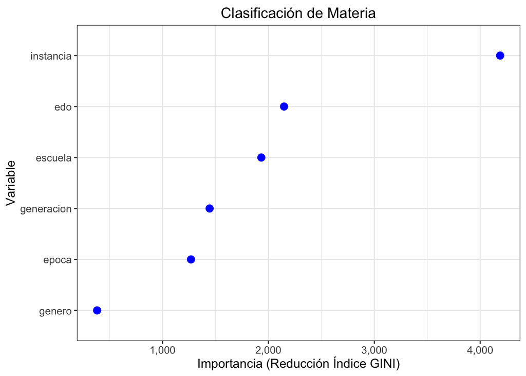

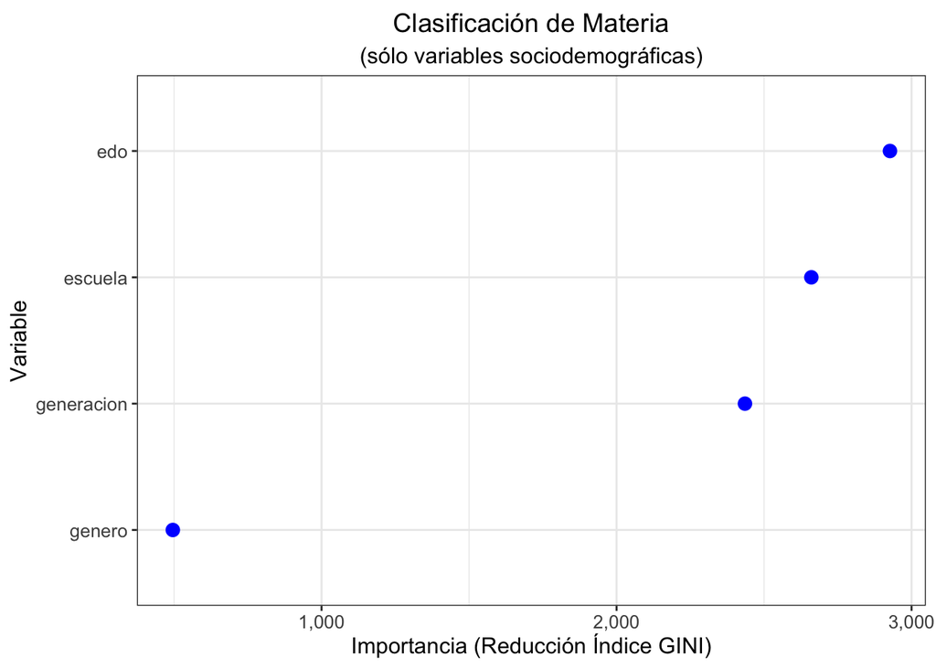

4. Evaluamos el ajuste del modelo:

Matriz de confusión del primer modelo: Clasificación de materias considerando todas las variables:

```
## Confusion Matrix and Statistics
##
##                 Reference
## Prediction       Administrativa Civil Común Constitucional Laboral Penal
##   Administrativa           1832   469   663             63     512   504
##   Civil                      78   711   242              0      56    78
##   Común                     723   608  2407            209     506   621
##   Constitucional             17     4    20             62       0     1
##   Laboral                   489   490   664              3    2528   377
##   Penal                      87    79    77              0      75   542
##
## Overall Statistics
##
##                Accuracy : 0.5116
##                  95% CI : (0.5038, 0.5194)
##     No Information Rate : 0.2578
##     P-Value [Acc > NIR] : < 2.2e-16
##
##                   Kappa : 0.3734
##
##  Mcnemar's Test P-Value : < 2.2e-16
##
## Statistics by Class:
##
##                      Class: Administrativa Class: Civil Class: Común
## Sensitivity                         0.5679      0.30114       0.5910
## Specificity                         0.8241      0.96621       0.7725
## Pos Pred Value                      0.4531      0.61030       0.4744
## Neg Pred Value                      0.8814      0.88723       0.8446
## Prevalence                          0.2042      0.14946       0.2578
## Detection Rate                      0.1160      0.04501       0.1524
## Detection Prevalence                0.2559      0.07375       0.3212
## Balanced Accuracy                   0.6960      0.63368       0.6817
##                      Class: Constitucional Class: Laboral Class: Penal
## Sensitivity                       0.183976         0.6875      0.25530
## Specificity                       0.997283         0.8331      0.97674
## Pos Pred Value                    0.596154         0.5555      0.63023
## Neg Pred Value                    0.982476         0.8978      0.89416
## Prevalence                        0.021333         0.2328      0.13439
## Detection Rate                    0.003925         0.1600      0.03431
## Detection Prevalence              0.006584         0.2881      0.05444
## Balanced Accuracy                 0.590630         0.7603      0.61602
```

Área bajo la curva del primer modelo: Clasificación de materias considerando todas las variables:

```
##
## Call:
## multiclass.roc.default(response = total_rf_mat_test$materia,     predictor = as.numeric(prueba_rf_1$materia))
##
## Data: as.numeric(prueba_rf_1$materia) with 6 levels of total_rf_mat_test$materia: Administrativa, Civil, Común, Constitucional, Laboral, Penal.
## Multi-class area under the curve: 0.6439
```

Matriz de confusión del segundo modelo: Clasificación de materias considerando sólo las variables sociodemográficas:

```
## Confusion Matrix and Statistics
##
##                 Reference
## Prediction       Administrativa Civil Común Constitucional Laboral Penal
##   Administrativa           1358   444   752             66     439   347
##   Civil                     140   623   272              7     111   107
##   Común                     827   817  2125            193     652   733
##   Constitucional              0     0     0              0       0     0
##   Laboral                   675   391   707             45    2353   326
##   Penal                     226    86   217             26     122   610
##
## Overall Statistics
##
##                Accuracy : 0.4475
##                  95% CI : (0.4397, 0.4553)
##     No Information Rate : 0.2578
##     P-Value [Acc > NIR] : < 2.2e-16
##
##                   Kappa : 0.2913
##
##  Mcnemar's Test P-Value : < 2.2e-16
##
## Statistics by Class:
##
##                      Class: Administrativa Class: Civil Class: Común
## Sensitivity                        0.42095      0.26387       0.5217
## Specificity                        0.83709      0.95259       0.7252
## Pos Pred Value                     0.39871      0.49444       0.3974
## Neg Pred Value                     0.84925      0.88044       0.8136
## Prevalence                         0.20422      0.14946       0.2578
## Detection Rate                     0.08597      0.03944       0.1345
## Detection Prevalence               0.21561      0.07976       0.3385
## Balanced Accuracy                  0.62902      0.60823       0.6235
##                      Class: Constitucional Class: Laboral Class: Penal
## Sensitivity                        0.00000         0.6399      0.28733
## Specificity                        1.00000         0.8231      0.95049
## Pos Pred Value                         NaN         0.5232      0.47397
## Neg Pred Value                     0.97867         0.8828      0.89573
## Prevalence                         0.02133         0.2328      0.13439
## Detection Rate                     0.00000         0.1490      0.03861
## Detection Prevalence               0.00000         0.2847      0.08147
## Balanced Accuracy                  0.50000         0.7315      0.61891
```

Área bajo la curva del segundo modelo: Clasificación de materias considerando sólo las variables sociodemográficas:

```
##
## Call:
## multiclass.roc.default(response = total_rf_mat_test_socio$materia,     predictor = as.numeric(prueba_rf_2$materia))
##
## Data: as.numeric(prueba_rf_2$materia) with 6 levels of total_rf_mat_test_socio$materia: Administrativa, Civil, Común, Constitucional, Laboral, Penal.
## Multi-class area under the curve: 0.6142
```

## Modelos de Regresión: Clasificación de instancias

1. Generamos nuevos datos de entrenamiento y prueba.
2. Realizamos regresión logística multinomial:

2.1. Clasificación de instancias considerando todas las variables.

2.2. Clasificación de instancias considerando sólo las variables sociodemográficas.

**NOTA:** Se toma a la instancia “Tribunales Colegiados de Circuito” como la categoría de referencia.

3. Determinamos qué coeficientes son relevantes.

Coeficientes más relevantes para primer modelo: Clasificación de instancias considerando todas las variables:

```
##                                                           Primera.Sala
## escuelaUniversidad de Colima                              3.966780e+63
## generacionPrevios                                         1.752095e+57
## escuelaEscuela de Jurisprudencia de Campeche              6.005058e+39
## escuelaColegio de San Nicolas                             7.159167e+29
## epocaSexta Época                                          5.893353e+25
## escuelaEscuela de Jurisprudencia de la Ciudad Guadalajara 2.748393e+24
## escuelaUniversidad Juarez Autonoma de Tabasco             1.943669e+17
## escuelaUniversidad de San Luis Potosi                     3.060490e+16
## escuelaUniversidad Iberoamericana                         3.401854e+15
## escuelaEscuela Libre de Derecho                           3.309721e+14
```

```
##                                                  Segunda.Sala
## escuelaEscuela de Jurisprudencia de Campeche    1.624065e+184
## escuelaUniversidad Juarez del Estado de Durango  2.116672e+74
## escuelaUniversidad Autonoma de Yucatan           2.103416e+64
## generacionPrevios                                5.409068e+57
## escuelaInstituto de ciencias y Artes de Oaxaca   2.823071e+48
## escuelaUniversidad de San Luis Potosi            1.843790e+44
## escuelaEscuela Libre de Derecho                  1.525122e+40
## escuelaUniversidad de La Sierra                  9.120733e+39
## escuelaUniversidad La Salle                      2.589239e+39
## escuelaUniversidad Autonoma de Queretaro         2.030295e+39
```

```
##                                              Tercera.Sala
## generacionPrevios                            3.944658e+56
## epocaSexta Época                             1.243183e+44
## escuelaUniversidad de Colima                 4.570772e+36
## escuelaEscuela de Jurisprudencia de Campeche 3.702033e+20
## edoZacatecas                                 7.866296e+19
## edoSinaloa                                   1.819005e+19
## epocaSéptima Época                           1.017537e+19
## edoCampeche                                  5.724700e+18
## epocaOctava Época                            2.247617e+18
## edoJalisco                                   1.076699e+18
```

```
##                                                   Cuarta.Sala
## generacionPrevios                                7.421879e+56
## escuelaUniversidad de Nuevo Leon                 1.363307e+42
## epocaSexta Época                                 1.490362e+37
## escuelaEscuela de Jurisprudencia de Campeche     2.851641e+35
## escuelaUniversidad de Colima                     2.528222e+35
## escuelaUniversidad Juarez Autonoma de Tabasco    1.391284e+22
## escuelaUniversidad Autonoma del Estado de Mexico 9.493327e+20
## escuelaUniversidad Intercontinental              1.982526e+16
## escuelaUniversidad Autonoma de Tamaulipas        1.384573e+14
## escuelaUniversidad Autonoma de Nuevo Leon        7.248741e+13
```

```
##                                                          Sala.Auxiliar
## generacionPrevios                                         2.703659e+73
## escuelaUniversidad de Colima                              3.542464e+52
## escuelaUniversidad Popular Autonoma del Estado de Puebla  1.250792e+41
## epocaSexta Época                                          1.827836e+32
## escuelaUniversidad de Nuevo Leon                          1.030623e+31
## generacionDepresion                                       4.888031e+27
## generacionPost Guerra                                     5.859929e+26
## generacionSegunda GM                                      9.237081e+25
## edoCampeche                                               1.110564e+24
## escuelaUniversidad de Puebla                              1.725411e+23
```

```
##                                                      Pleno
## generacionPrevios                             3.029393e+57
## escuelaUniversidad de Colima                  2.299232e+46
## epocaSexta Época                              7.696950e+25
## escuelaUniversidad Juarez Autonoma de Tabasco 1.623755e+25
## escuelaEscuela de Jurisprudencia de Campeche  1.614980e+22
## edoTexas                                      2.033403e+03
## epocaSéptima Época                            4.239366e+01
## generacionDepresion                           2.604770e+01
## edoNuevo Leon                                 1.317999e+01
## edoZacatecas                                  9.128976e+00
```

Coeficientes más relevantes para segundo modelo: Clasificación de instancias considerando sólo las variables sociodemográficas:

```
##                                                           Primera.Sala
## escuelaUniversidad de Colima                              8.326900e+13
## escuelaEscuela de Jurisprudencia de Campeche              2.813069e+11
## generacionPrevios                                         1.698425e+11
## escuelaColegio de San Nicolas                             2.612743e+09
## escuelaUniversidad de San Luis Potosi                     2.222692e+09
## escuelaEscuela de Jurisprudencia de la Ciudad Guadalajara 2.005499e+08
## escuelaUniversidad Iberoamericana                         1.905073e+06
## escuelaEscuela Libre de Derecho                           2.300606e+05
## escuelaUniversidad de Monterrey                           1.854406e+05
## escuelaEscuela Nacional de Estudios Profesionales Aragon  1.583124e+05
```

```
##                                                 Segunda.Sala
## escuelaEscuela de Jurisprudencia de Campeche    1.514548e+30
## escuelaUniversidad de San Luis Potosi           1.715012e+15
## escuelaUniversidad Juarez del Estado de Durango 1.493471e+14
## escuelaUniversidad Autonoma de Yucatan          6.329411e+11
## generacionPrevios                               2.141893e+11
## escuelaInstituto de ciencias y Artes de Oaxaca  1.433375e+10
## escuelaEscuela Libre de Derecho                 3.760299e+08
## escuelaUniversidad de La Sierra                 1.332063e+08
## escuelaUniversidad La Salle                     6.263685e+07
## escuelaUniversidad Autonoma de Queretaro        6.069403e+07
```

```
##                                              Tercera.Sala
## generacionPrevios                            1.329149e+11
## edoCampeche                                  1.719608e+05
## edoZacatecas                                 7.063009e+04
## escuelaEscuela de Jurisprudencia de Campeche 2.661817e+04
## edoSinaloa                                   2.340494e+04
## edoGuanajuato                                2.823904e+03
## edoBaja California                           2.467319e+03
## edoCiudad de Mexico                          2.417614e+03
## edoJalisco                                   1.190672e+03
## edoDurango                                   9.132374e+02
```

```
##                                                       Cuarta.Sala
## generacionPrevios                                    7.828963e+11
## escuelaUniversidad de Colima                         5.812976e+06
## escuelaEscuela de Jurisprudencia de Campeche         1.914344e+06
## escuelaUniversidad Autonoma de Queretaro             2.844258e+04
## escuelaUniversidad Autonoma de Tamaulipas            1.829404e+04
## escuelaEscuela Libre de Derecho                      9.120089e+03
## escuelaBenemerita Universidad Autonoma de Puebla     5.567300e+03
## escuelaUniversidad de Guadalajara                    4.460835e+03
## escuelaUniversidad Michoacana de San Nicolas Hidalgo 2.036742e+03
## escuelaUniversidad Autonoma de Nuevo Leon            1.628226e+03
```

```
##                                                          Sala.Auxiliar
## generacionPrevios                                         4.686309e+16
## escuelaUniversidad Popular Autonoma del Estado de Puebla  3.852668e+09
## edoCampeche                                               3.348326e+07
## generacionDepresion                                       1.860098e+07
## escuelaUniversidad de Colima                              1.811323e+07
## generacionSegunda GM                                      5.116656e+05
## escuelaUniversidad de Nuevo Leon                          9.245495e+04
## escuelaBenemerita Universidad Autonoma de Puebla          3.793054e+04
## generacionPost Guerra                                     3.065168e+03
## escuelaUniversidad Autonoma de Hidalgo                    1.176485e+03
```

```
##                                                      Pleno
## generacionPrevios                             1.792428e+11
## escuelaUniversidad de Colima                  3.108689e+08
## escuelaEscuela de Jurisprudencia de Campeche  1.228900e+06
## edoTexas                                      3.373951e+03
## generacionDepresion                           4.840153e+01
## edoNuevo Leon                                 3.259310e+01
## escuelaUniversidad Juarez Autonoma de Tabasco 1.522275e+01
## edoJalisco                                    7.874994e+00
## escuelaUniversidad Autonoma de Zacatecas      7.583428e+00
## edoZacatecas                                  6.885428e+00
```

4. Evaluamos el ajuste del modelo:

Matriz de confusión del primer modelo: Clasificación de instancias considerando todas las variables:

```
## Confusion Matrix and Statistics
##
##                                    Reference
## Prediction                          Cuarta Sala Pleno Primera Sala
##   Cuarta Sala                               678   108           32
##   Pleno                                      36   279           17
##   Primera Sala                               17   213          727
##   Sala Auxiliar                               0     0            0
##   Segunda Sala                               23   328           22
##   Tercera Sala                               41   147            2
##   Tribunales Colegiados de Circuito          90   650          196
##                                    Reference
## Prediction                          Sala Auxiliar Segunda Sala Tercera Sala
##   Cuarta Sala                                   7           46           15
##   Pleno                                         0           20           33
##   Primera Sala                                  0            6           13
##   Sala Auxiliar                               108            0            0
##   Segunda Sala                                  1         1450            5
##   Tercera Sala                                  0           33          402
##   Tribunales Colegiados de Circuito             0          843          136
##                                    Reference
## Prediction                          Tribunales Colegiados de Circuito
##   Cuarta Sala                                                      67
##   Pleno                                                           145
##   Primera Sala                                                    107
##   Sala Auxiliar                                                     2
##   Segunda Sala                                                    341
##   Tercera Sala                                                    150
##   Tribunales Colegiados de Circuito                             11805
##
## Overall Statistics
##
##                Accuracy : 0.7988
##                  95% CI : (0.793, 0.8044)
##     No Information Rate : 0.6523
##     P-Value [Acc > NIR] : < 2.2e-16
##
##                   Kappa : 0.6089
##
##  Mcnemar's Test P-Value : NA
```

[output cut: 24 more lines]

```
## Pos Pred Value                   0.51871
## Neg Pred Value                   0.98912
## Prevalence                       0.03123
## Detection Rate                   0.02078
## Detection Prevalence             0.04007
## Balanced Accuracy                0.82283
##                      Class: Tribunales Colegiados de Circuito
## Sensitivity                                            0.9356
## Specificity                                            0.7152
## Pos Pred Value                                         0.8604
## Neg Pred Value                                         0.8555
## Prevalence                                             0.6523
## Detection Rate                                         0.6104
## Detection Prevalence                                   0.7094
## Balanced Accuracy                                      0.8254
```

Área bajo la curva del primer modelo: Clasificación de instancias considerando todas las variables:

```
##
## Call:
## multiclass.roc.default(response = total_r_inst_test$instancia,     predictor = as.numeric(prueba_5$instancia))
##
## Data: as.numeric(prueba_5$instancia) with 7 levels of total_r_inst_test$instancia: Cuarta Sala, Pleno, Primera Sala, Sala Auxiliar, Segunda Sala, Tercera Sala, Tribunales Colegiados de Circuito.
## Multi-class area under the curve: 0.7465
```

Matriz de confusión del segundo modelo: Clasificación de instancias considerando sólo las variables sociodemográficas:

```
## Confusion Matrix and Statistics
##
##                                    Reference
## Prediction                          Cuarta Sala Pleno Primera Sala
##   Cuarta Sala                               586   105           33
##   Pleno                                      10   250           94
##   Primera Sala                                0   167          643
##   Sala Auxiliar                               6     8            4
##   Segunda Sala                               33   401           23
##   Tercera Sala                                0    24            3
##   Tribunales Colegiados de Circuito         250   770          196
##                                    Reference
## Prediction                          Sala Auxiliar Segunda Sala Tercera Sala
##   Cuarta Sala                                   7           57           40
##   Pleno                                         0           22           41
##   Primera Sala                                  0            6            0
##   Sala Auxiliar                               108            1            9
##   Segunda Sala                                  1         1430           43
##   Tercera Sala                                  0            2           33
##   Tribunales Colegiados de Circuito             0          880          438
##                                    Reference
## Prediction                          Tribunales Colegiados de Circuito
##   Cuarta Sala                                                      23
##   Pleno                                                            74
##   Primera Sala                                                     91
##   Sala Auxiliar                                                     3
##   Segunda Sala                                                    438
##   Tercera Sala                                                      2
##   Tribunales Colegiados de Circuito                             11986
##
## Overall Statistics
##
##                Accuracy : 0.7774
##                  95% CI : (0.7715, 0.7833)
##     No Information Rate : 0.6523
##     P-Value [Acc > NIR] : < 2.2e-16
##
##                   Kappa : 0.5441
##
##  Mcnemar's Test P-Value : < 2.2e-16
```

[output cut: 24 more lines]

```
## Pos Pred Value                  0.515625
## Neg Pred Value                  0.970379
## Prevalence                      0.031229
## Detection Rate                  0.001706
## Detection Prevalence            0.003309
## Balanced Accuracy               0.526491
##                      Class: Tribunales Colegiados de Circuito
## Sensitivity                                            0.9500
## Specificity                                            0.6231
## Pos Pred Value                                         0.8255
## Neg Pred Value                                         0.8691
## Prevalence                                             0.6523
## Detection Rate                                         0.6197
## Detection Prevalence                                   0.7507
## Balanced Accuracy                                      0.7866
```

```
##
## Call:
## multiclass.roc.default(response = total_r_inst_test_socio$instancia,     predictor = as.numeric(prueba_6$instancia))
##
## Data: as.numeric(prueba_6$instancia) with 7 levels of total_r_inst_test_socio$instancia: Cuarta Sala, Pleno, Primera Sala, Sala Auxiliar, Segunda Sala, Tercera Sala, Tribunales Colegiados de Circuito.
## Multi-class area under the curve: 0.7269
```

## Árbol aleatorio: Clasificación de instancias:

1. Generamos nuevos datos de entrenamiento y prueba.
2. Generamos los bosques aleatorios:
3. Evaluamos la importancia de las variables:

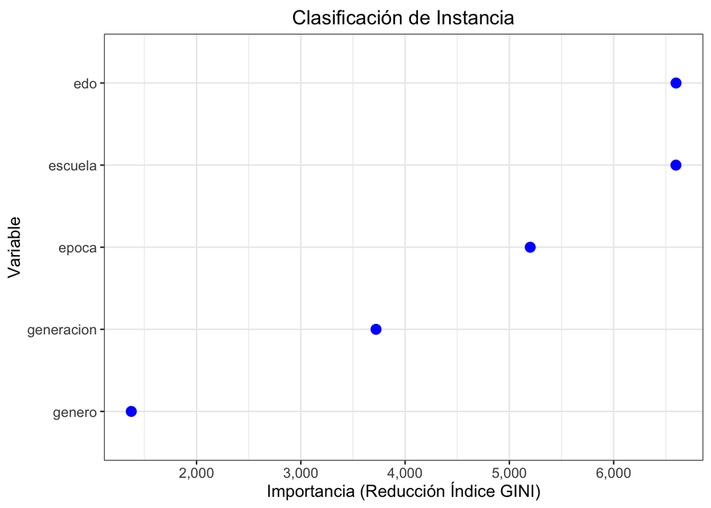

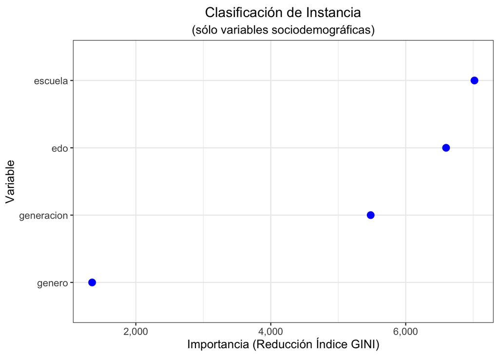

4. Evaluamos el ajuste del modelo:

Matriz de confusión del primer modelo: Clasificación de instancias considerando todas las variables:

```
## Confusion Matrix and Statistics
##
##                                    Reference
## Prediction                          Cuarta Sala Pleno Primera Sala
##   Cuarta Sala                               674   126           38
##   Pleno                                      45   200            2
##   Primera Sala                                5    17          171
##   Sala Auxiliar                               0     0            0
##   Segunda Sala                               11   139           17
##   Tercera Sala                               17    31            2
##   Tribunales Colegiados de Circuito         133  1212          766
##                                    Reference
## Prediction                          Sala Auxiliar Segunda Sala Tercera Sala
##   Cuarta Sala                                   6           93           28
##   Pleno                                         0           23           42
##   Primera Sala                                  0           21            8
##   Sala Auxiliar                               108            0            0
##   Segunda Sala                                  1          758            2
##   Tercera Sala                                  0            2          103
##   Tribunales Colegiados de Circuito             1         1501          421
##                                    Reference
## Prediction                          Tribunales Colegiados de Circuito
##   Cuarta Sala                                                      24
##   Pleno                                                            10
##   Primera Sala                                                     13
##   Sala Auxiliar                                                     2
##   Segunda Sala                                                    120
##   Tercera Sala                                                     11
##   Tribunales Colegiados de Circuito                             12437
##
## Overall Statistics
##
##                Accuracy : 0.7472
##                  95% CI : (0.741, 0.7533)
##     No Information Rate : 0.6523
##     P-Value [Acc > NIR] : < 2.2e-16
##
##                   Kappa : 0.4161
##
##  Mcnemar's Test P-Value : NA
```

[output cut: 24 more lines]

```
## Pos Pred Value                  0.620482
## Neg Pred Value                  0.973872
## Prevalence                      0.031229
## Detection Rate                  0.005325
## Detection Prevalence            0.008583
## Balanced Accuracy               0.583584
##                      Class: Tribunales Colegiados de Circuito
## Sensitivity                                            0.9857
## Specificity                                            0.4001
## Pos Pred Value                                         0.7551
## Neg Pred Value                                         0.9373
## Prevalence                                             0.6523
## Detection Rate                                         0.6430
## Detection Prevalence                                   0.8516
## Balanced Accuracy                                      0.6929
```

Área bajo la curva del primer modelo: Clasificación de instancias considerando todas las variables:

```
##
## Call:
## multiclass.roc.default(response = total_rf_inst_test$instancia,     predictor = as.numeric(prueba_rf_5$instancia))
##
## Data: as.numeric(prueba_rf_5$instancia) with 7 levels of total_rf_inst_test$instancia: Cuarta Sala, Pleno, Primera Sala, Sala Auxiliar, Segunda Sala, Tercera Sala, Tribunales Colegiados de Circuito.
## Multi-class area under the curve: 0.7238
```

Matriz de confusión del segundo modelo: Clasificación de instancias considerando sólo las variables sociodemográficas:

```
## Confusion Matrix and Statistics
##
##                                    Reference
## Prediction                          Cuarta Sala Pleno Primera Sala
##   Cuarta Sala                               458    92            8
##   Pleno                                       0   131            0
##   Primera Sala                                0    76          319
##   Sala Auxiliar                               6     8            4
##   Segunda Sala                                1   104           17
##   Tercera Sala                                6    25            6
##   Tribunales Colegiados de Circuito         414  1289          642
##                                    Reference
## Prediction                          Sala Auxiliar Segunda Sala Tercera Sala
##   Cuarta Sala                                   1          173           13
##   Pleno                                         0           22           19
##   Primera Sala                                  0            1            0
##   Sala Auxiliar                                17            1            9
##   Segunda Sala                                  0          852            2
##   Tercera Sala                                  0            5           52
##   Tribunales Colegiados de Circuito            98         1344          509
##                                    Reference
## Prediction                          Tribunales Colegiados de Circuito
##   Cuarta Sala                                                       7
##   Pleno                                                             9
##   Primera Sala                                                     45
##   Sala Auxiliar                                                     3
##   Segunda Sala                                                     75
##   Tercera Sala                                                     11
##   Tribunales Colegiados de Circuito                             12467
##
## Overall Statistics
##
##                Accuracy : 0.7392
##                  95% CI : (0.7329, 0.7453)
##     No Information Rate : 0.6523
##     P-Value [Acc > NIR] : < 2.2e-16
##
##                   Kappa : 0.3847
##
##  Mcnemar's Test P-Value : < 2.2e-16
```

[output cut: 24 more lines]

```
## Pos Pred Value                  0.495238
## Neg Pred Value                  0.971304
## Prevalence                      0.031229
## Detection Rate                  0.002689
## Detection Prevalence            0.005429
## Balanced Accuracy               0.541632
##                      Class: Tribunales Colegiados de Circuito
## Sensitivity                                            0.9881
## Specificity                                            0.3611
## Pos Pred Value                                         0.7437
## Neg Pred Value                                         0.9418
## Prevalence                                             0.6523
## Detection Rate                                         0.6446
## Detection Prevalence                                   0.8667
## Balanced Accuracy                                      0.6746
```

Área bajo la curva del segundo modelo: Clasificación de instancias considerando sólo las variables sociodemográficas:

```
##
## Call:
## multiclass.roc.default(response = total_rf_inst_test_socio$instancia,     predictor = as.numeric(prueba_rf_6$instancia))
##
## Data: as.numeric(prueba_rf_6$instancia) with 7 levels of total_rf_inst_test_socio$instancia: Cuarta Sala, Pleno, Primera Sala, Sala Auxiliar, Segunda Sala, Tercera Sala, Tribunales Colegiados de Circuito.
## Multi-class area under the curve: 0.6014
```